# Zurich Map

The following code will generate a map from the city of Zurich showing the birth rate for each city borough. The map also shows the public space in Zurich, these spaces varied from small to big park.

First, the library which will be need to open the files and create the map are imported. Tydiverse to read and manipulate the dataset, tmap, tmaptools to create and visualize data distribution in maps, rgdal, geojsonio, maptools to open and manipulate geographic data.

```r
library(tidyverse)
library(tmaptools)
library(sf)
library(tmap)
library(rgdal)
```

```r
library(maptools)
library(geojsonio)
```

After this, the shapefile with boundaries for the district of Zurich and the dataframe with the information regarding birth rate are open.

```r
ZurichMap <- st_read("stadtkreis/Stadtkreis.shp")
birth.rate <- read.csv("birth.rate.csv", header = TRUE, sep=",")
```

To quickly check if the data has been read correctly, the “class” function is used. This indicates that the Zurich boundary map is read as a simple feature object.

```r
class(ZurichMap)
```

```
## [1] "sf"         "data.frame"
```

```r
class(birth.rate)
```

```
## [1] "data.frame"
```

Before to map the birth rate for each borough (“Kreis”), the dataframe need to be join with the shapefile. To know, the name of the attributes that are similar, the function head is used. This give the first six lines for each datasets.

```r
head(ZurichMap)
```

```
## Simple feature collection with 6 features and 2 fields
## geometry type:  POLYGON
## dimension:      XY
## bbox:           xmin: 2676225 ymin: 1241584 xmax: 2689666 ymax: 1254306
## epsg (SRID):    2056
## proj4string:    +proj=somerc +lat_0=46.95240555555556 +lon_0=7.439583333333333 +k_0=1 +x_0=2600000 +y_0=1200000 +ellps=bessel +units=m +no_defs
##   knr    kname                       geometry
## 1   7  Kreis 7 POLYGON ((2683861 1246724, ...
## 2  11 Kreis 11 POLYGON ((2684316 1250652, ...
## 3   9  Kreis 9 POLYGON ((2680390 1248341, ...
## 4   2  Kreis 2 POLYGON ((2682297 1247016, ...
## 5  10 Kreis 10 POLYGON ((2680538 1249895, ...
## 6   3  Kreis 3 POLYGON ((2682297 1247016, ...
```

```r
head(birth.rate)
```

```
##   kreis average.birth.rate
## 1     1              10.05
## 2     2              13.93
## 3     3              13.54
## 4     4              10.88
## 5     5              12.97
## 6     6              12.28
```

The attribute “knr” and “kreis” are both similar. The birth.rate dataframe will therefore be append to ZurichMap joining these two attributes.

```r
ZurichBirthMap <- append_data(ZurichMap, birth.rate, key.shp="knr", key.data="kreis")
```

```
## Keys match perfectly.
```

Now, the map can be plot. The function qtm is used to generate the map of Zurich. Once the layer with the boroughs of Zurich has been made, it is possible to add some other layers to personalized the map. Essential features such as a title, a compass, a scale bar can also be add as new layer.

```r
tmap_mode("plot")
```

```
## tmap mode set to plotting
```

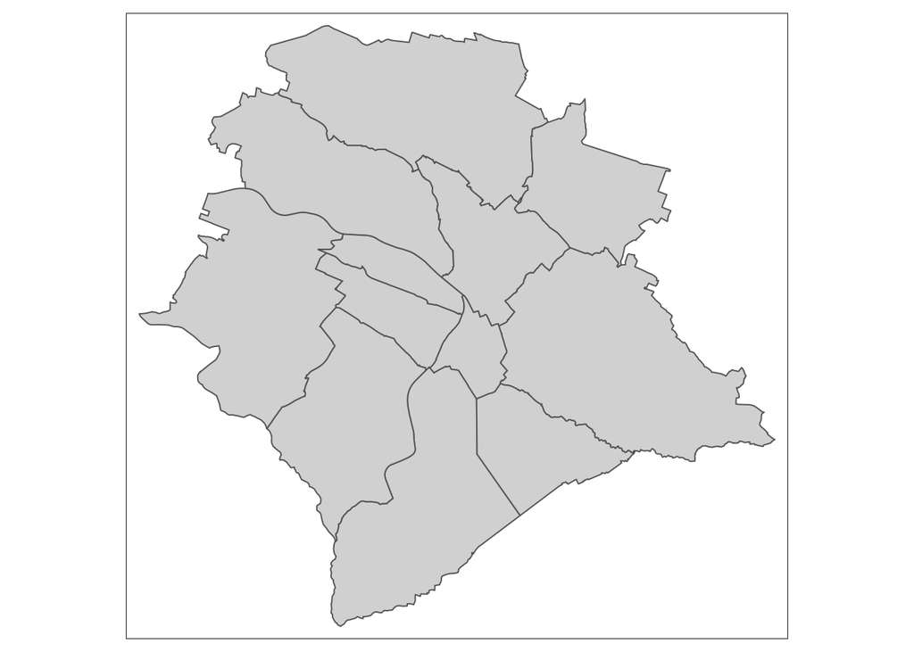

```r
qtm(ZurichBirthMap)
```

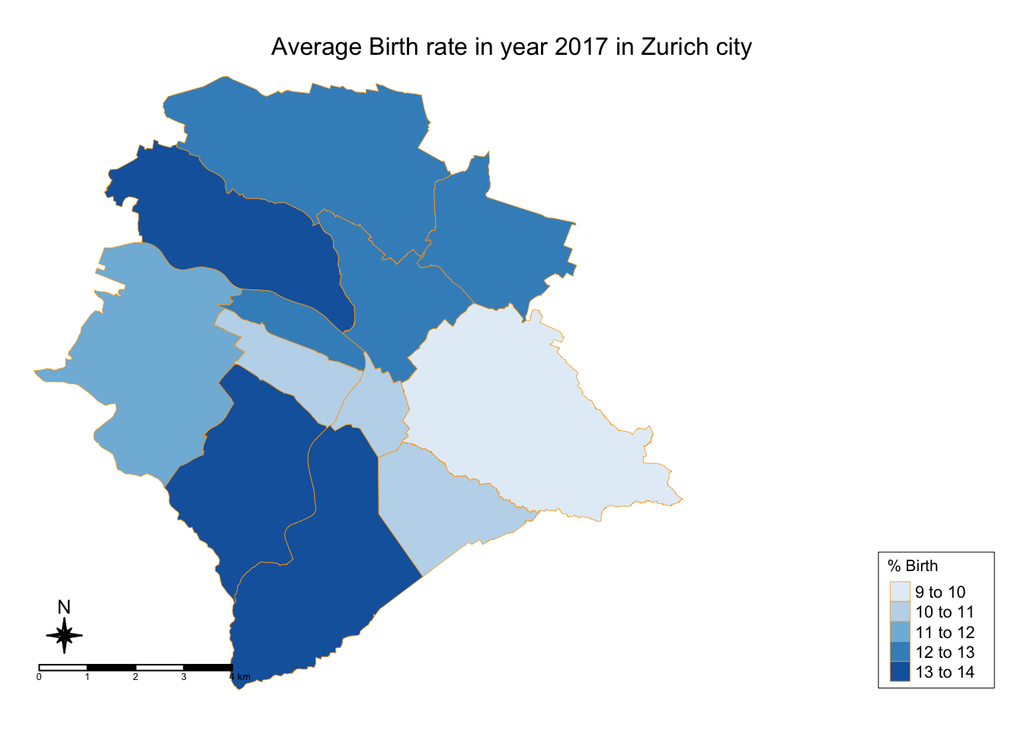

```r
tm_shape(ZurichBirthMap)+
  tm_polygons("average.birth.rate",
              title="% Birth",
              breaks=c(9,10,11,12,13,14),
              palette="Blues",
              lwd=0.4,
              border.col="orange")+
  tm_layout(main.title="Average Birth rate in year 2017 in Zurich city", main.title.size=1, main.title.position = c("center","top"), frame=FALSE, legend.frame = TRUE,legend.frame.lwd = 0.5, legend.outside=TRUE, legend.title.size = 0.8, legend.position = c("right","bottom"))+
  tm_compass(position = c("left","bottom"),type="8star",size=1.5)+
  tm_scale_bar(position = c("left","bottom"),size=0.4)
```

Now, we would like to see where there are some open spaces either small or big parks in Zurich city. The park geolocation can be direclty read from the web using the library geojson.

```r
park <- geojson_read("https://data.stadt-zuerich.ch/dataset/park/resource/570b4622-eb7a-4ad3-8b4f-028d30b6cb8c/download/park.json", what="sp")
```

Would it be possible to add the spatial park location to the map previously made? Let’s try!

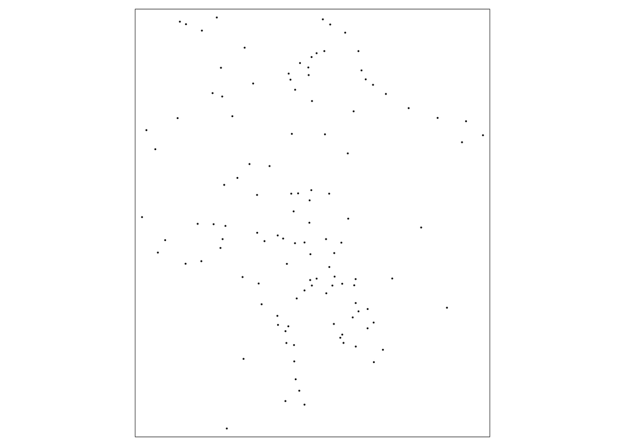

```r
qtm(park)
```

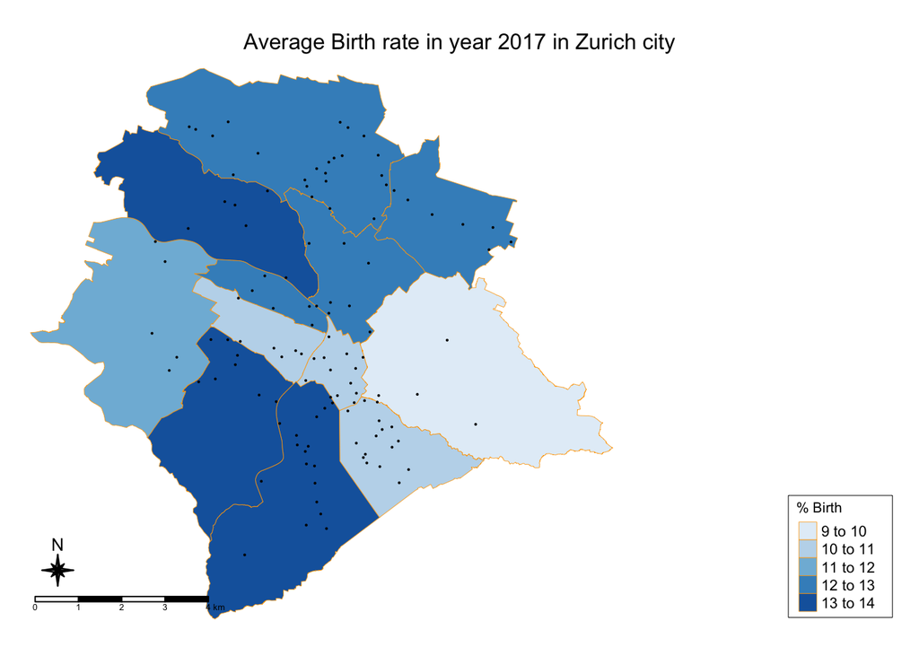

```r
tm_shape(ZurichBirthMap)+
  tm_polygons("average.birth.rate",
              title="% Birth",
              breaks=c(9,10,11,12,13,14),
              palette="Blues",
              lwd=0.4,
              border.col="orange")+
  tm_layout(main.title="Average Birth rate in year 2017 in Zurich city", main.title.size=1, main.title.position = c("center","top"), frame=FALSE, legend.frame = TRUE,legend.frame.lwd = 0.5, legend.outside=TRUE, legend.title.size = 0.8, legend.position = c("right","bottom"))+
  tm_compass(position = c("left","bottom"),type="8star",size=1.5)+
  tm_scale_bar(position = c("left","bottom"),size=0.4)+
qtm(park)
```

What if, we want to select only the playgrounds? I would need to convert my json file into a dataframe, but I don’t know how to do that. So let’s import my park as a shapefile.

```r
park.data <- st_read("park/Park.shp")
summary(park.data)
```

```
##                           infrastruk                       name
##  NULL;NULL                     :37   Aemtleranlage           :  1
##  Spielplatz;NULL               :12   Alfred-Altherr-Terrasse :  1
##  Spielplatz;Liegewiese         : 5   Allmend Brunau          :  1
##  Behinderten-WC;NULL           : 4   Allmend Stettbach       :  1
##  Besuchenden-WC_Spielplatz;NULL: 3   Alter Botanischer Garten:  1
##  Besuchenden-WC;NULL           : 3   Althoosstrasse          :  1
##  (Other)                       :54   (Other)                 :112
##                                                                                                                          www
##  http://www.stadt-zuerich.ch/ted/de/index/gsz/natur-_und_erlebnisraeume/park-_und_gruenanlagen/belvoirpark.html            : 2
##  http://www.stadt-zuerich.ch/ted/de/index/gsz/natur-_und_erlebnisraeume/park-_und_gruenanlagen/aemtleranlage.html          : 1
##  http://www.stadt-zuerich.ch/ted/de/index/gsz/natur-_und_erlebnisraeume/park-_und_gruenanlagen/alter_botanischergarten.html: 1
##  http://www.stadt-zuerich.ch/ted/de/index/gsz/natur-_und_erlebnisraeume/park-_und_gruenanlagen/andreaspark.html            : 1
##  http://www.stadt-zuerich.ch/ted/de/index/gsz/natur-_und_erlebnisraeume/park-_und_gruenanlagen/arboretum.html              : 1
##  (Other)                                                                                                                   :65
##  NA's                                                                                                                      :47
##           geometry
##  POINT        :118
##  epsg:2056    :  0
##  +proj=some...:  0
##
##
##
##
```

```r
playground <- park.data[grep("Spielplatz", park.data$infrastruk),]
```

With summary(), I can see all the information that related to the park data. I notice that each parks have different attributes, for example some of them have a playground, coffee or/and wc facilities. I want to select only the park with a playground. Let’s check quickly, if the data have now fewer dots (parks)!

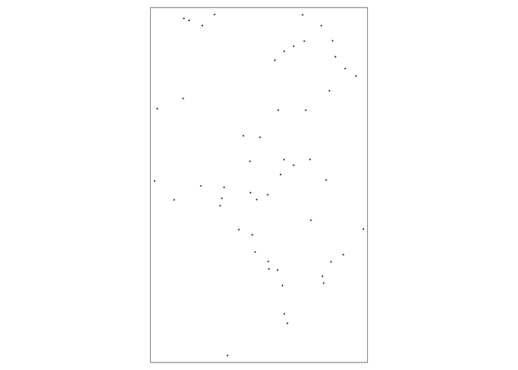

```r
qtm(playground)
```

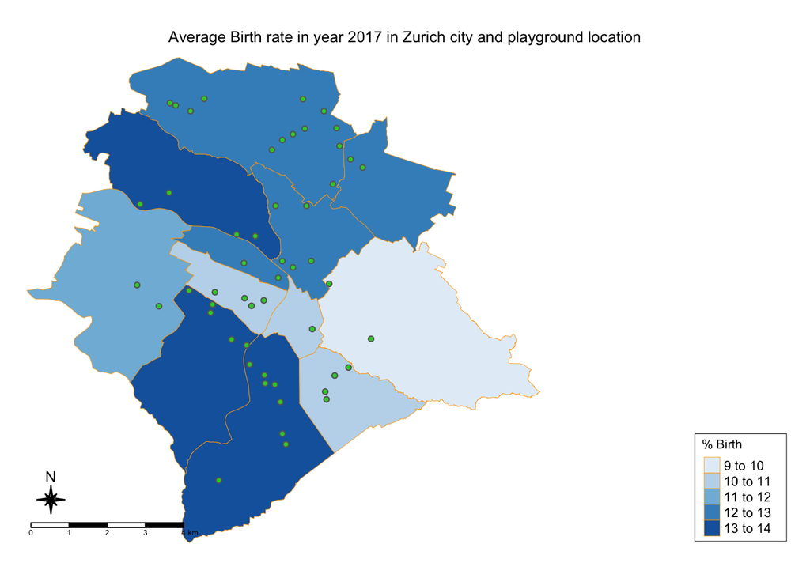

```r
tm_shape(ZurichBirthMap)+
  tm_polygons("average.birth.rate",
              title="% Birth",
              breaks=c(9,10,11,12,13,14),
              palette="Blues",
              lwd=0.4,
              border.col="orange")+
  tm_layout(main.title="Average Birth rate in year 2017 in Zurich city and playground location", main.title.size=0.8, main.title.position = c("center","top"), frame=FALSE, legend.frame = TRUE,legend.frame.lwd = 0.5, legend.outside=TRUE, legend.title.size = 0.8, legend.position = c("right","bottom"))+
  tm_compass(position = c("left","bottom"),type="8star",size=1.5)+
  tm_scale_bar(position = c("left","bottom"),size=0.4)+
qtm(playground,symbols.col ="limegreen", symbols.size=0.1)
```

And if we want to save the map as an image.

```r
Zurich <- tm_shape(ZurichBirthMap)+
  tm_polygons("average.birth.rate",
              title="% Birth",
              breaks=c(9,10,11,12,13,14),
              palette="Blues",
              lwd=0.4,
              border.col="orange")+
  tm_layout(main.title="Average Birth rate in year 2017 in Zurich city and playground location", main.title.size=0.8, main.title.position = c("center","top"), frame=FALSE, legend.frame = TRUE,legend.frame.lwd = 0.5, legend.outside=TRUE, legend.title.size = 0.8, legend.position = c("right","bottom"))+
  tm_compass(position = c("left","bottom"),type="8star",size=1.5)+
  tm_scale_bar(position = c("left","bottom"),size=0.4)+
qtm(playground,symbols.col ="limegreen", symbols.size=0.1)
tmap_save(Zurich, "Zurichmap.png", height = 6)
```

```
## Map saved to /Users/audevuilliomenet/Documents/MSc. Smart Cities/GI Systems and Science/Zurich Map/Zurichmap.png
```

```
## Resolution: 1901.727 by 1800 pixels
```

```
## Size: 6.339089 by 6 inches (300 dpi)
```

Just because it is fancy, here is an interactive the map in an interactive way. The function tmap_mode() is now set as “view” in contrast to “plot”.

```r
tmap_mode("view")
```

```
## tmap mode set to interactive viewing
```

```r
tm_shape(ZurichBirthMap)+
  tm_polygons("average.birth.rate",
              title="% Birth",
              breaks=c(9,10,11,12,13,14),
              palette="Blues",
              alpha = 0.5,
              lwd=0.4,
              border.col="orange")+
  tm_layout(main.title="Average Birth rate in year 2017 in Zurich city and playground location", main.title.size=1, main.title.position = c("center","top"), frame=FALSE, legend.frame = TRUE,legend.frame.lwd = 0.5, legend.outside=TRUE, legend.title.size = 0.8, legend.position = c("right","bottom"))+
  tm_compass(position = c("left","bottom"),type="8star",size=1.5)+
  tm_scale_bar(position = c("left","bottom"),size=0.4)+
qtm(playground,symbols.col ="limegreen", symbols.size=0.3)
```

```
## Compass not supported in view mode.
```

```
## legend.postion is used for plot mode. Use view.legend.position in tm_view to set the legend position in view mode.
```

[interactive chart not shown]